# Clase 1. Fundamentos conceptuales de la visualización de datos

Diplomatura en Ciencias Sociales Computacionales y Humanidades Digitales - UNSAM

Seminario de Visualización de datos en R

Florencia Piñeyrúa y Nayla Sol Garcilazo

# Fundamentos conceptuales

¿Por qué es importante visualizar datos?

● Actividad central en la actividad científica o profesional

● Ayuda a comunicar ideas complejas

● Aproximadamente como el 80% de la información que recibimos la captamos por el sistema visual

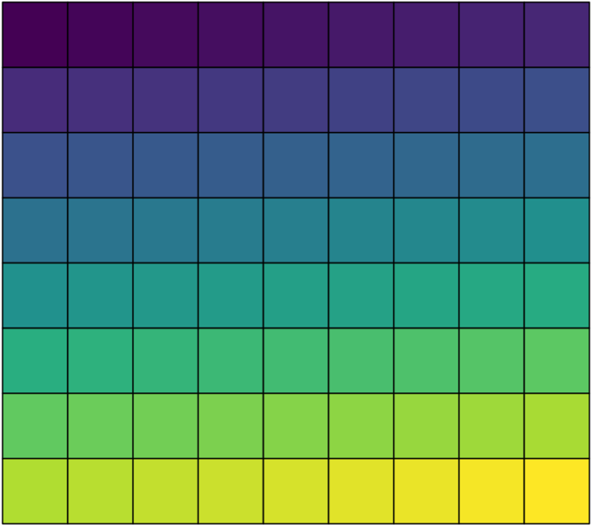

## ¿Qué es un mal gráfico?

**MALOS DATOS**

Un gráfico puede ser más persuasivo que una tabla, pero también más peligroso si está mal hecho. Visualizar es un acto de poder, podemos iluminar patrones o podemos distorsionarlos.

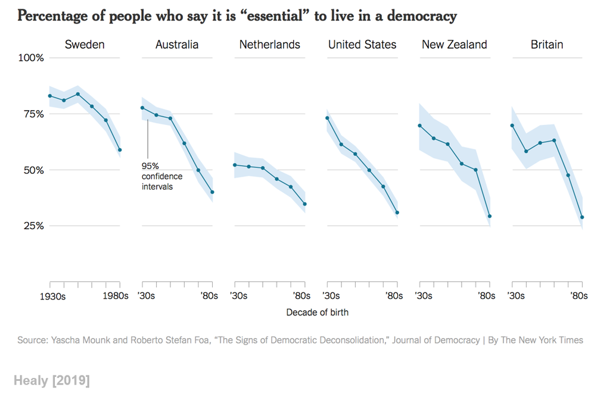

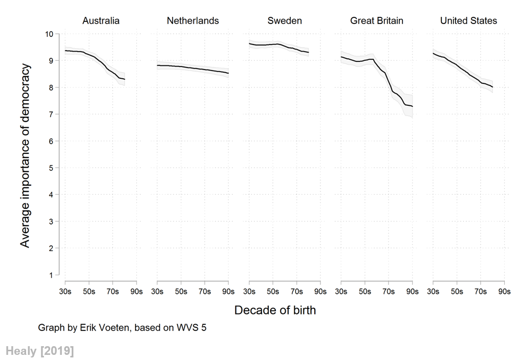

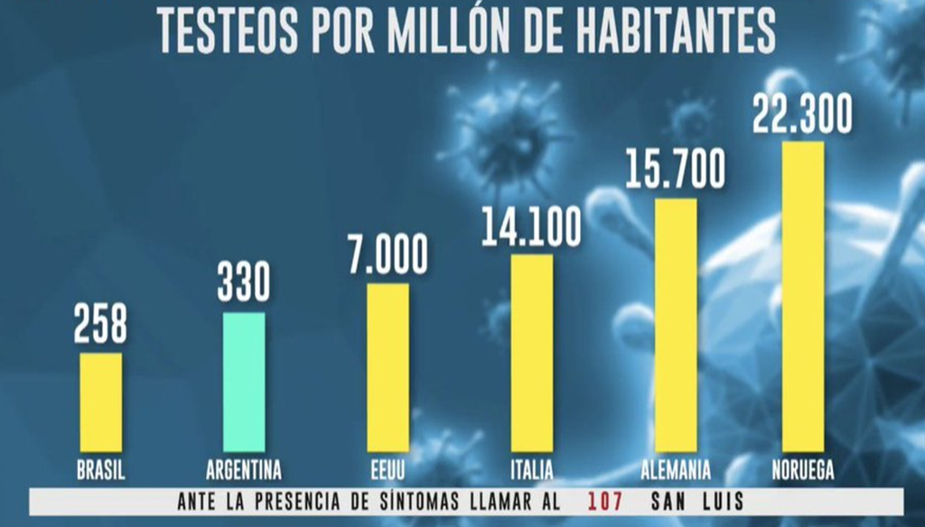

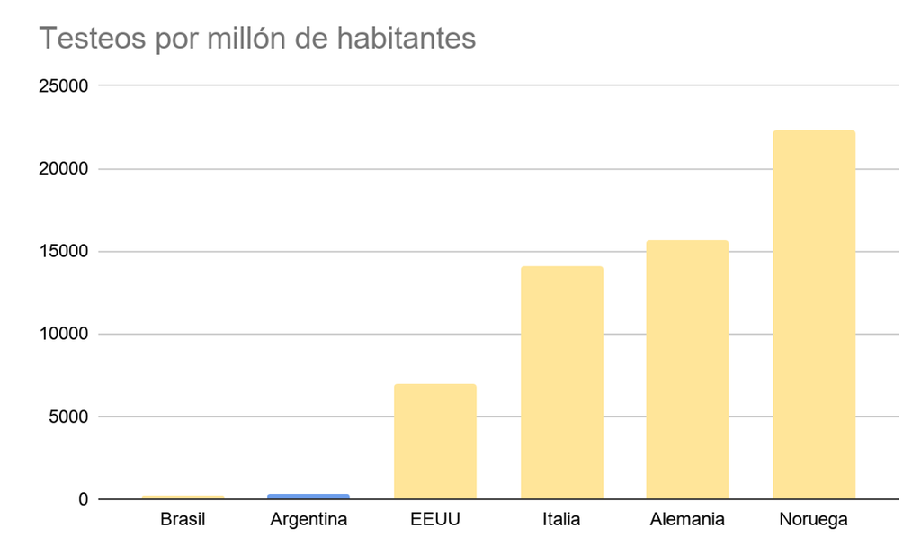

## ¿Qué es un mal gráfico?

**MAL GUSTO**

Cuando el diseño visual termina ocultando o distrayendo de lo importante. El mal gusto en los gráficos no es un problema de diseño superficial, sino que puede hacer que la gente malinterprete los datos.

> “Above all else show the data” - Edward Tufte

Edward Tufte, uno de los grandes referentes en teoría de la visualización, defiende el minimalismo gráfico. Su planteo es simple: cuanta menos tinta no informativa haya en un gráfico, mejor.

Tufte llamó *chart junk* o *basura gráfica* a todos los elementos visuales que no aportan información:

● Rejillas excesivas.

● Sombras en 3D.

● Perspectivas que deforman proporciones.

[figure not shown]

¿Qué aporta el mapa?

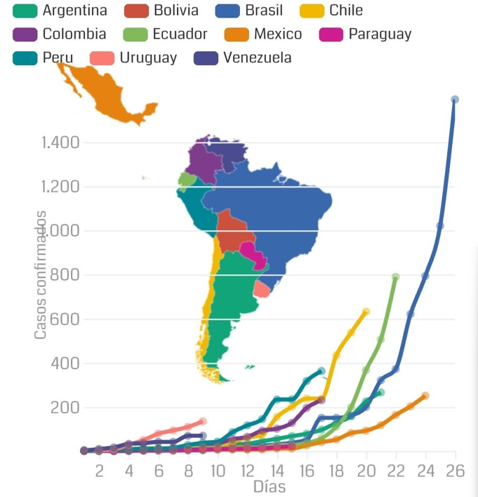

¿Cuánto tardan en entender qué país está peor en este gráfico?

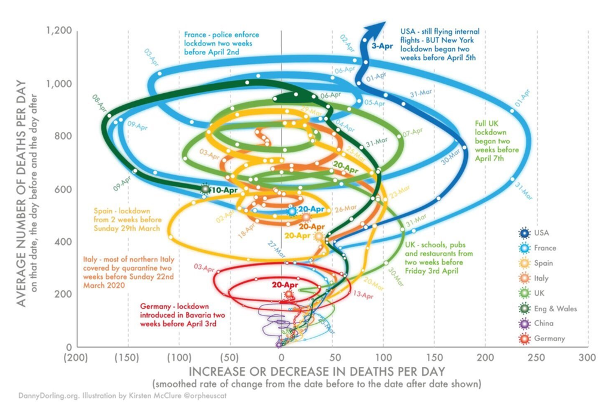

## Data-ink ratio

Un buen gráfico maximiza la tinta dedicada a la información y minimiza la tinta desperdiciada en adornos.

Tufte propusó la métrica *Data-ink ratio* para cuantificar la proporción de la tinta que efectivamente muestra datos.

[figure not shown]

¿Qué elementos podría borrar sin perder información?

El objetivo es quedarnos con la mínima cantidad de elementos que transmitan los datos de forma clara. Si puedo quitar una línea, una sombra, un ícono o un mapa sin que cambie el mensaje, entonces sobra.

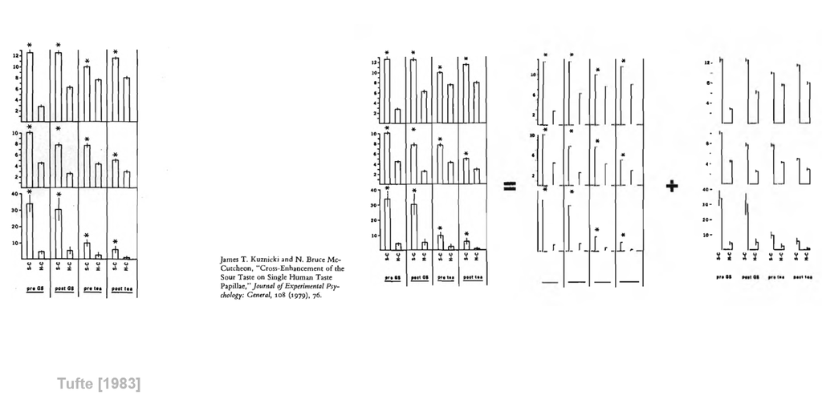

Lo estético (a veces) puede ser un obstáculo para la percepción

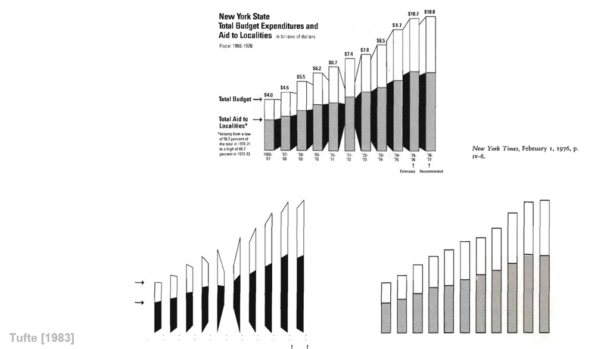

Cuando tenemos distintas variantes gráficas (boxplots, violin plots, etc.), ¿qué elegiría Tufte?

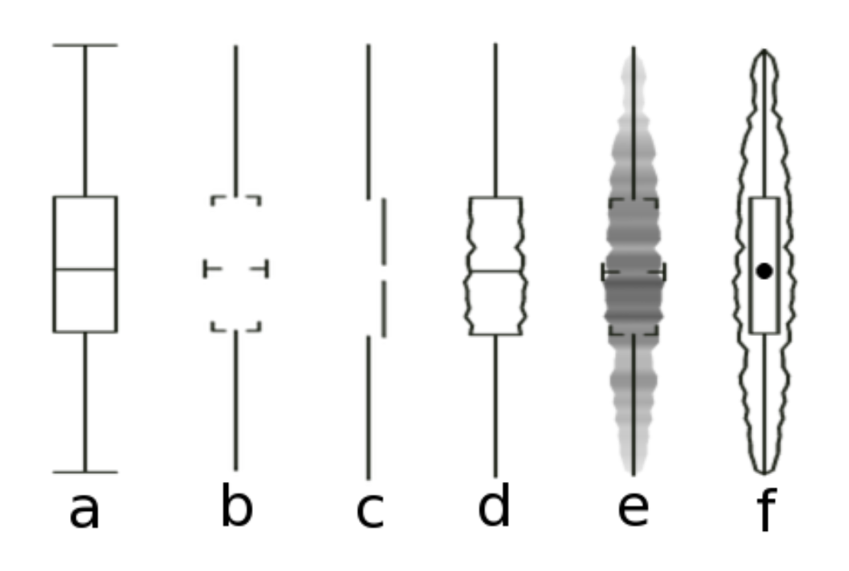

No es un problema solo estético: la forma puede alterar la interpretación.

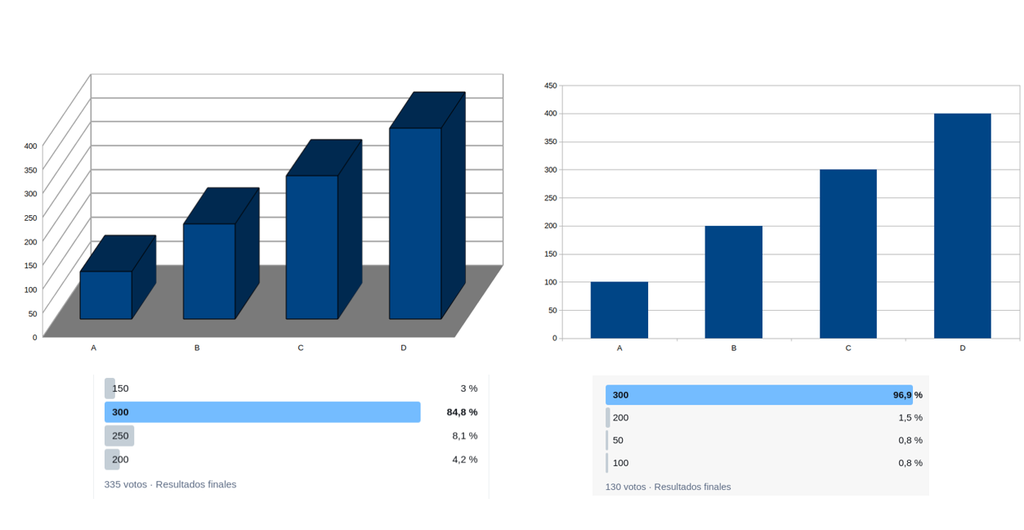

[figure not shown]

## ¿Qué es un mal gráfico?

**MALA PERCEPCIÓN**

Un gráfico representa visualmente la distribución de una variable a través de ciertos canales, como ser la forma, color, tamaño, transparencia, posición, etc. En otras palabras: en los datos se codifican en un gráfico a través de estos canales que se expresan en objetos visuales. El problema es que nuestro sistema visual no siempre interpreta esos canales de manera fiel: podemos caer en ilusiones visuales.

[figure not shown]

El tablero de Adelson

[figure not shown]

Los bordes y contrastes son más efectivos para transmitir estructura que el color puro. En visualización, muchas veces la posición y forma comunican mejor que el color.

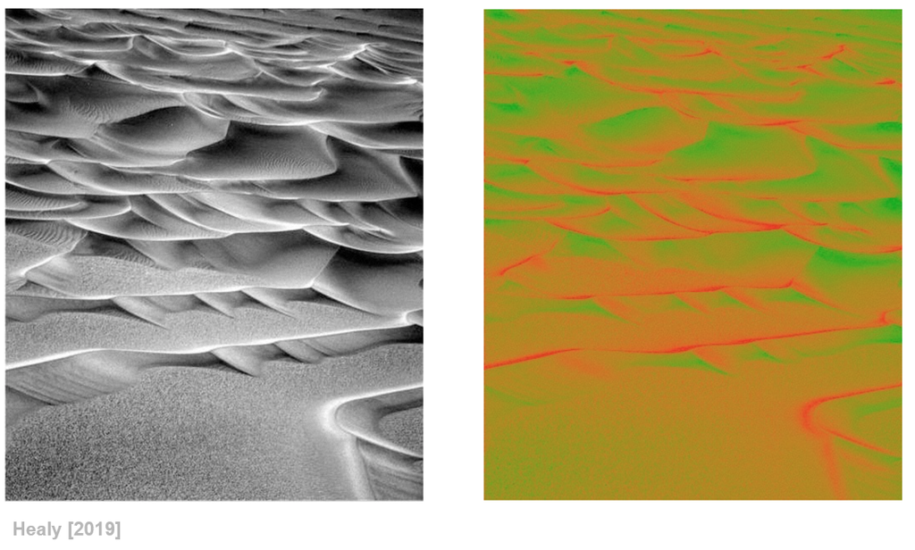

Algunos objetos gráficos son más visibles en nuestro campo visual que otros, independientemente de su valor real.

[figure not shown]

## Búsqueda visual y efectividad de los canales

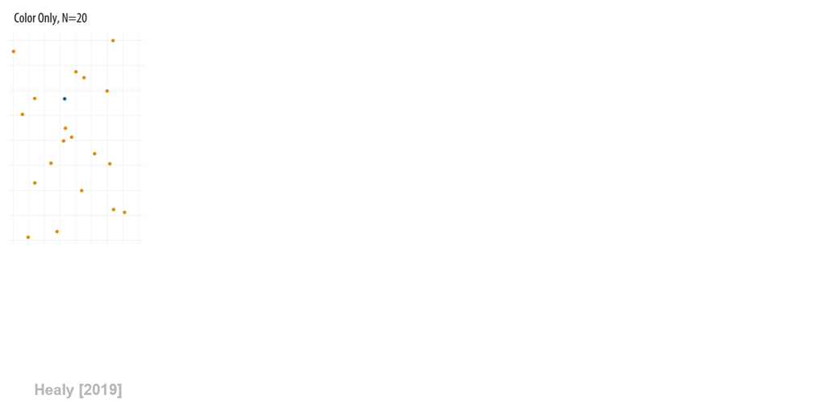

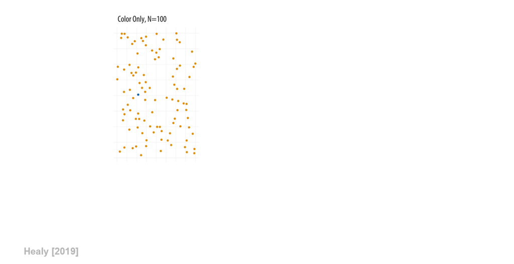

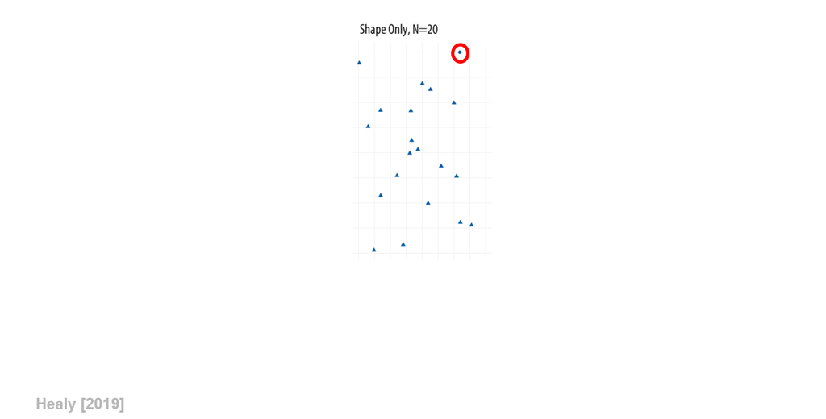

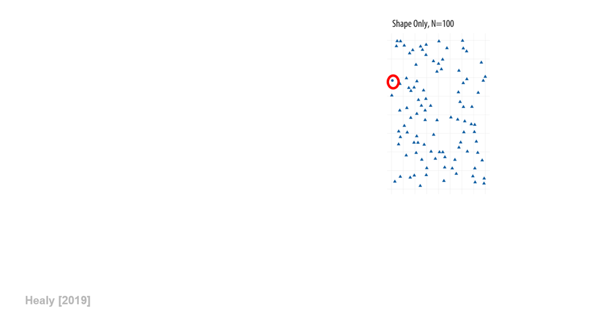

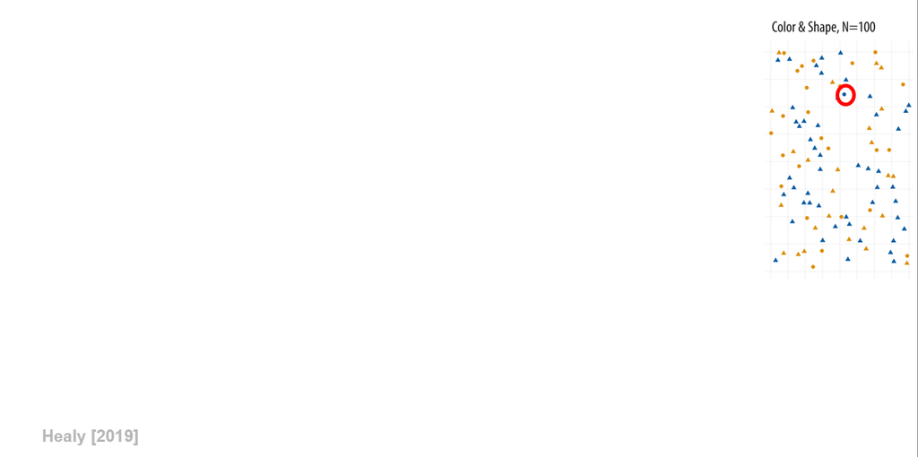

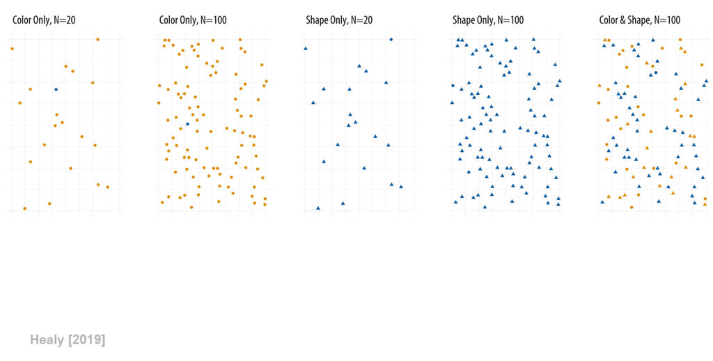

En términos generales:

● El canal color parece ser el más efectivo cuando necesitamos resaltar un elemento en un conjunto grande.

● La forma es menos eficiente cuando la cantidad de elementos aumenta.

## Búsqueda visual y sobrecarga de canales

La percepción humana tiene un límite: demasiados canales simultáneos saturan la capacidad de lectura.

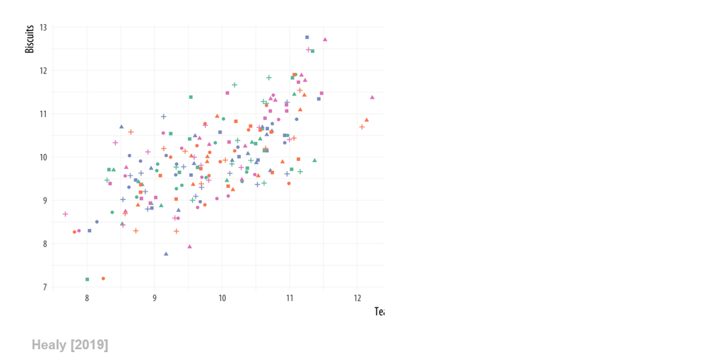

Cuando reducimos la cantidad de canales, el patrón se vuelve más legible.

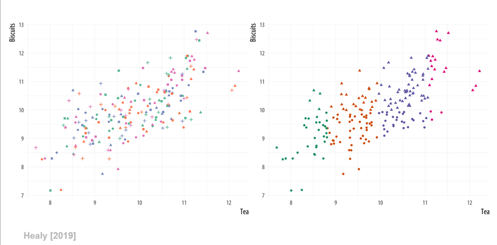

## Percepción de patrones y aleatoriedad

¿Cuál de las dos distribuciones es más aleatoria?

[figure not shown]

## Las reglas Gestalt

● *Proximidad*: objetos que están cerca entre sí son percibidos como relacionados.

● *Similaridad*: objetos parecidos (color, forma, tamaño) son agrupados en la percepción.

● *Conexión*: cuando los objetos están unidos visualmente (por una línea o un marco) los percibimos como parte de un mismo conjunto.

● *Continuidad*: completamos líneas u objetos parcialmente ocultos siguiendo patrones familiares.

● *Cierre*: tendemos a “cerrar” mentalmente las formas incompletas.

● *Figura y fondo*: diferenciamos lo que está en primer plano de lo que queda en el fondo.

● *Destino común*: cuando varios elementos se mueven en la misma dirección, los percibimos como una unidad.

Principios de proximidad y similaridad

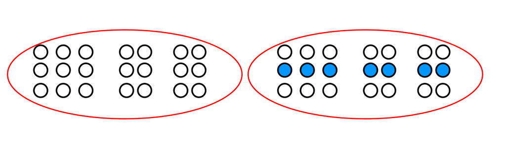

Principios de continuidad, conexión y cierre

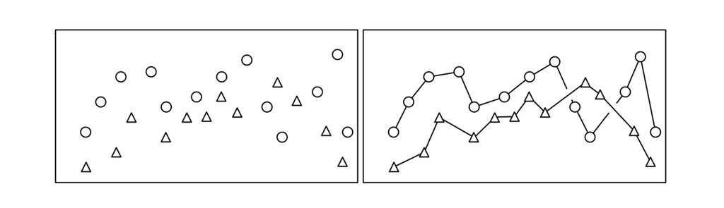